# activity09

### Activity 9

Damion Huppert

```python
import numpy as np
import matplotlib.pyplot as plt
```

##### Question 1-a

$$ X = \begin{bmatrix} 1 & 1 \\ -2 & -2 \end{bmatrix} $$ $$ y = \begin{bmatrix} 2 \\ -4 \end{bmatrix} $$ $$ w = \begin{bmatrix} w_1 \\ w_2 \end{bmatrix} $$ $$ Xw = \begin{bmatrix} w_1 + w_2 \\ -2w_1 -2w_2 \end{bmatrix} $$ $$ w_1 + w_2 = 2 $$ $$ w_1 + w_2 = 2 $$

The solution is not unique because both equations are the same, the solution lies on the line $w_1 + w_2 = 2 $

$$ \min_w ||Xw - y||_2^2 = 0 $$

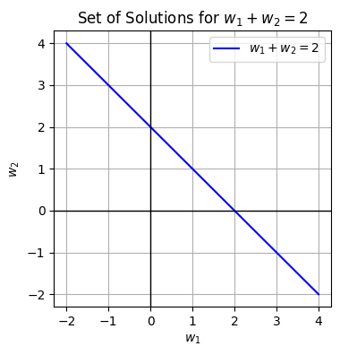

```python
w1 = np.linspace(-2, 4, 100)
w2 = 2 - w1

plt.figure(figsize=(4,4))
plt.plot(w1, w2, label=r'$w_1 + w_2 = 2$', color='blue')

plt.axhline(0, color='black', linewidth=1)
plt.axvline(0, color='black', linewidth=1)
plt.xlabel(r'$w_1$')
plt.ylabel(r'$w_2$')
plt.title('Set of Solutions for $w_1 + w_2 = 2$')
plt.legend()
plt.grid()
plt.show()
```

##### Question 1-b

$$ \min_w ||w||_2^2 \quad \text{subject to} \quad w_1 + w_2 = 2 $$ By analyzing the graph we can see $w$ will be smallest when $ w = \begin{bmatrix} 1 \\ 1 \end{bmatrix} $
This solution is unique, because there is only one value that is the minimum of $ ||w||_2^2 = \sqrt{2} $

The error at the solution is 0 because (1, 1) lies on the line $w_1 + w_2 = 2$

##### Questoin 1-c

$$ \hat{w} = \arg\min_w \left\{ ||Xw - y||_2^2 + \lambda ||w||_2^2 \right\} $$ $ \|Xw - y\|_2^2 = (Xw - y)^T (Xw - y) \text{ and } \|w\|_2^2 = w^Tw $ $$ f(w) = (Xw - y)^T (Xw - y) + \lambda w^Tw $$ $ (Xw - y)^T = (Xw)^T -y^T \text{ and } y^T(Xw) = y(Xw)^T $ $$ f(w) = (Xw)^T (Xw) - 2(Xw)^T y + y^T y + \lambda w^T w $$ $$ f(w) = w^TX^TXw - 2w^TX^Ty + y^T y + \lambda w^T w $$ To find the minimum take the gradient and set it equal to 0

## $$ \nabla_w f(w) = 2 X^T X w - 2 X^T y + 2 \lambda w = 0 $$ $$ 2 X^T X w + 2 \lambda w = 2 X^T y $$ $$ X^T X w + \lambda w = X^T y $$ $$ (X^T X + \lambda I)w = X^T y $$

$$ X^T X = \begin{bmatrix} 5 & 5 \\ 5 & 5 \end{bmatrix} $$ $$ A = X^T X + \lambda I = \begin{bmatrix} 5 + \lambda & 5 \\ 5 & 5 + \lambda \end{bmatrix} $$ $$ w = A^{-1}X^T y $$ $$ A^{-1} = \begin{bmatrix} 5 + \lambda & 5 \\ 5 & 5 + \lambda \end{bmatrix}^{-1} = \frac{1}{25 + 10\lambda + \lambda^2 - 25} \begin{bmatrix} 5+\lambda & -5 \\ -5 & 5+\lambda \end{bmatrix} $$ $$ A^{-1} = \frac{1}{\lambda(10 + \lambda)} \begin{bmatrix} 5+\lambda & -5 \\ -5 & 5+\lambda \end{bmatrix} $$ $$ w = \frac{1}{\lambda(10 + \lambda)} \begin{bmatrix} 5+\lambda & -5 \\ -5 & 5+\lambda \end{bmatrix} \begin{bmatrix} 10 \\ 10 \end{bmatrix} $$ $$ w = \frac{1}{\lambda(10 + \lambda)} \begin{bmatrix} 10(5+\lambda) - 50 \\ 10(5+\lambda) -50 \end{bmatrix} $$ $$ w = \frac{10(5+\lambda) - 50}{\lambda(10 + \lambda)} \begin{bmatrix} 1 \\ 1 \end{bmatrix} $$ $$ w = \frac{50 + 10\lambda - 50}{\lambda(10 + \lambda)} \begin{bmatrix} 1 \\ 1 \end{bmatrix} $$ $$ w = \frac{10\lambda}{\lambda(10 + \lambda)} \begin{bmatrix} 1 \\ 1 \end{bmatrix} $$ $$ w = \frac{10}{(10 + \lambda)} \begin{bmatrix} 1 \\ 1 \end{bmatrix} $$

```python
X = np.array([[1, 1], [-2, -2]])
y = np.array([2, -4])
print(X.T @ X)
print()
print(X.T @ y)
```

```
[[5 5]
 [5 5]]

[10 10]
```

##### Questoin 1-d

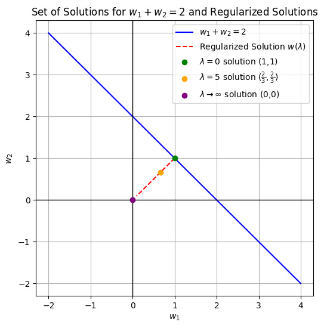

```python
w1_line = np.linspace(-2, 4, 100)
w2_line = 2 - w1_line

lambda_vals = np.linspace(0, 100, 100)

w1_reg = 10 / (10 + lambda_vals)
w2_reg = 10 / (10 + lambda_vals)

plt.figure(figsize=(6, 6))
plt.plot(w1_line, w2_line, label=r'$w_1 + w_2 = 2$', color='blue')

plt.plot(w1_reg, w2_reg, label=r'Regularized Solution $w(\lambda)$', color='red', linestyle='dashed')

plt.scatter([1], [1], color='green', label=r'$\lambda = 0$ solution (1,1)', zorder=3)
plt.scatter([2/3], [2/3], color='orange', label=r'$\lambda = 5$ solution $(\frac{2}{3}, \frac{2}{3})$', zorder=3)
plt.scatter([0], [0], color='purple', label=r'$\lambda \to \infty$ solution (0,0)', zorder=3)

# Formatting
plt.axhline(0, color='black', linewidth=1)
plt.axvline(0, color='black', linewidth=1)
plt.xlabel(r'$w_1$')
plt.ylabel(r'$w_2$')
plt.title('Set of Solutions for $w_1 + w_2 = 2$ and Regularized Solutions')
plt.legend()
plt.grid()
plt.show()
```

##### Question 2-a

Columns of X: $$ c_1 = \begin{bmatrix} 1 \\ 1 \\ 1 \\ 1 \end{bmatrix} \quad c_2 = \begin{bmatrix} \gamma \\ -\gamma \\ -\gamma \\ \gamma \end{bmatrix} $$ $$ c_1 \cdot c_2 = (1)(\gamma) + (1)(-\gamma) + (1)(-\gamma) + (1)(\gamma) = \gamma - \gamma - \gamma + \gamma = 0 $$

Therefore because the dot product is always 0 $ c_1 $ and $ c_2 $ are orthoganal $ \forall \gamma $

##### Question 2-b

$$ X = \begin{bmatrix} 1 & \gamma \\ 1 & -\gamma \\ 1 & -\gamma \\ 1 & \gamma\end{bmatrix} $$ $$ U = \begin{bmatrix} u_{11} & u_{12} \\ u_{21} & u_{22} \\ u_{31} & u_{31} \\ u_{41} & u_{42} \end{bmatrix} $$ $$ \Sigma = \begin{bmatrix} s_{11} & 0 \\ 0 & s_{22} \end{bmatrix} $$ $$ U \times \Sigma = \begin{bmatrix} u_{11} s_{11} & u_{12} s_{22} \\ u_{21} s_{11} & u_{22} s_{22} \\ u_{31} s_{11} & u_{31} s_{22} \\ u_{41} s_{11} & u_{42} s_{22} \end{bmatrix} $$ $$ U = \begin{bmatrix} u_{11} & u_{12} \\ u_{21} & u_{22} \\ u_{31} & u_{32} \\ u_{41} & u_{42} \end{bmatrix} $$ $$ \Sigma = \begin{bmatrix} s_{11} & 0 \\ 0 & s_{22} \end{bmatrix} $$ From $ X = U \Sigma $:

- $ u_{11} s_{11} = 1 $
- $ u_{12} s_{22} = \gamma $
- $ u_{21} s_{11} = 1 $
- $ u_{22} s_{22} = -\gamma $
- $ u_{31} s_{11} = 1 $
- $ u_{32} s_{22} = -\gamma $
- $ u_{41} s_{11} = 1 $
- $ u_{42} s_{22} = \gamma $

$$ U = \begin{bmatrix} 1 & 1 \\ 1 & -1 \\ 1 & -1 \\ 1 & 1 \end{bmatrix} $$ $$ \Sigma = \begin{bmatrix} 1 & 0 \\ 0 & \gamma \end{bmatrix} $$

##### Question 2-c

$$ \min_w ||Xw - y||_2^2 = \min_w ||(U\Sigma)w - y||_2^2 $$ $$ w = \left( (U\Sigma)^T (U\Sigma) \right)^{-1} (U\Sigma)^T y $$ $ (U\Sigma)^T (U\Sigma) = \Sigma^T U^T U \Sigma $ $$ w = \left( \Sigma^T U^T U \Sigma \right)^{-1} \Sigma^T U^T y $$

```python
U = np.array([[1, 1], [1, -1], [1, -1], [1, 1]])
print(U.T @ U)
```

```
[[4 0]
 [0 4]]
```

##### Question 2-d

$$ y = \begin{bmatrix} 1 \\ 0 \\ 0 \\ 1 \end{bmatrix} $$ $$ U^T U = \begin{bmatrix} 4 & 0 \\ 0 & 4 \end{bmatrix} $$ $$ w = \left( \Sigma^T U^T U \Sigma \right)^{-1} \Sigma^T U^T y $$ $\Sigma^T U^T U \Sigma =\begin{bmatrix} 1 & 0 \\ 0 & \gamma \end{bmatrix} \begin{bmatrix} 4 & 0 \\ 0 & 4 \end{bmatrix} \begin{bmatrix} 1 & 0 \\ 0 & \gamma \end{bmatrix} = \begin{bmatrix} 4 & 0 \\ 0 & 4\gamma^2 \end{bmatrix} $
$$ $$ $(\Sigma^T U^T U \Sigma)^{-1} = \begin{bmatrix} 4 & 0 \\ 0 & 4\gamma^2 \end{bmatrix}^{-1} = \frac{1}{16\gamma^2}\begin{bmatrix} 4\gamma^2 & 0 \\ 0 & 4 \end{bmatrix} = \begin{bmatrix} \frac{1}{4} & 0 \\ 0 & \frac{1}{4\gamma^2} \end{bmatrix}$ $$ $$ $\Sigma^T U^T y= \begin{bmatrix} 1 & 0 \\ 0 & \gamma \end{bmatrix} \begin{bmatrix} 1 & 1 & 1 & 1 \\ 1 & -1 & -1 & 1 \end{bmatrix} \begin{bmatrix} 1 \\ 0 \\ 0 \\ 1 \end{bmatrix} = \begin{bmatrix} 2 \\ 2\gamma \end{bmatrix} $

$$ w = \begin{bmatrix} \frac{1}{4} & 0 \\ 0 & \frac{1}{4\gamma^2} \end{bmatrix} \begin{bmatrix} 2 \\ 2\gamma \end{bmatrix} = \begin{bmatrix} \frac{1}{2} \\[3pt] \frac{1}{2\gamma} \end{bmatrix} $$

As $\gamma \to 0$ $ w \to \begin{bmatrix} \frac{1}{2} \\ \infty \end{bmatrix} $

##### Question 2-e

## $ \gamma = 0.1 $ $$ \text{condition number} = \frac{1}{0.1} = 10 $$ $$ ||w||_2^2 = \sqrt{\left( \frac{1}{2} \right)^2 + \left( \frac{1}{2 \times 0.1} \right)^2} = 5.025$$

$ \gamma = 10^{-8} $ $$ \text{condition number} = \frac{1}{10^{-8}} = 10^8 $$ $$ ||w||_2^2 = \sqrt{\left( \frac{1}{2} \right)^2 + \left( \frac{1}{2 \times 10^{-8}} \right)^2} = 5 \times 10^7 $$

##### Question 2-f

$$ w_0 = \begin{bmatrix} \frac{1}{2} \\[3pt] \frac{1}{2\gamma} \end{bmatrix} $$ $$ w_\epsilon = \begin{bmatrix} \frac{1}{4} & 0 \\ 0 & \frac{1}{4\gamma^2} \end{bmatrix} \begin{bmatrix} 2 + \epsilon \\ 2\gamma + \epsilon\gamma \end{bmatrix} = \begin{bmatrix} \frac{1}{2} + \frac{1}{4} \epsilon \\[3pt] \frac{2 + \epsilon}{4\gamma} \end{bmatrix} $$

```python
gamma = 0.1
epsilon = 0.01
w_0 = np.array([1/2, 1/(2*gamma)])
w_epsilon = np.array([[.5 + .25*epsilon],[(2+epsilon)/(4*gamma)]])
print("gamma = 0.1")
print("w_0 =", w_0)
print("w_epsilon =", w_epsilon)

gamma = 10**-8
w_0 = np.array([1/2, 1/(2*gamma)])
w_epsilon = np.array([[.5 + .25*epsilon],[(2+epsilon)/(4*gamma)]])
print("gamma = 10^-8")
print("w_0 =", w_0)
print("w_epsilon =", w_epsilon)
```

```
gamma = 0.1
w_0 = [0.5 5. ]
w_epsilon = [[0.5025]
 [5.025 ]]
gamma = 10^-8
w_0 = [5.e-01 5.e+07]
w_epsilon = [[5.025e-01]
 [5.025e+07]]
```

##### Question 2-g

## $$ U = \begin{bmatrix} 1 & 1 \\ 1 & -1 \\ 1 & -1 \\ 1 & 1 \end{bmatrix} $$ $$ \Sigma = \begin{bmatrix} 1 & 0 \\ 0 & \gamma \end{bmatrix} $$ $$ y = \begin{bmatrix} 1 \\ 0 \\ 0 \\ 1 \end{bmatrix} $$ $$ y_\epsilon = \begin{bmatrix} 1 + \epsilon \\ 0 \\ 0 \\ 1 \end{bmatrix} $$

$$ w = \arg\min_w ||Xw - y||_2^2 + \lambda ||w||_2^2 $$ From 1-c: $$ w = ( X^T X + \lambda I )^{-1}X^T y $$ $ X = U \Sigma $ $$ w = ( (U \Sigma)^T U \Sigma + \lambda I )^{-1}(U \Sigma)^T y $$ $$ w = \left( \Sigma^T \Sigma + \lambda I \right)^{-1} \Sigma^T U^T y. $$

$$ w_0 = \left( \Sigma^T \Sigma + \lambda I \right)^{-1} \Sigma^T U^T y. $$ $$ w_\epsilon = \left( \Sigma^T \Sigma + \lambda I \right)^{-1} \Sigma^T U^T y_\epsilon. $$ $$ w_0 = \begin{bmatrix} \frac{2}{1 + \lambda} \\[3pt] \frac{2\gamma}{\gamma^2 + \lambda} \end{bmatrix}, \quad w_\epsilon = \begin{bmatrix} \frac{2 + \epsilon}{1 + \lambda} \\[3pt] \frac{2\gamma + \gamma \epsilon}{\gamma^2 + \lambda} \end{bmatrix} $$

```python
lambda_ = 0.1
gamma = 0.5
epsilon = 0.01

w_0 = np.array([
    2 / (1 + lambda_),
    (2 * gamma) / (gamma**2 + lambda_)
])

w_epsilon = np.array([
    (2 + epsilon) / (1 + lambda_),
    (2 * gamma + gamma * epsilon) / (gamma**2 + lambda_)
])

print("gamma = 0.1")
print("w_0 =", w_0)
print("w_epsilon =", w_epsilon)

epsilon = 10**-8

w_0 = np.array([
    2 / (1 + lambda_),
    (2 * gamma) / (gamma**2 + lambda_)
])

w_epsilon = np.array([
    (2 + epsilon) / (1 + lambda_),
    (2 * gamma + gamma * epsilon) / (gamma**2 + lambda_)
])
print("gamma = 10^-8")
print("w_0 =", w_0)
print("w_epsilon =", w_epsilon)
```

```
gamma = 0.1
w_0 = [1.81818182 2.85714286]
w_epsilon = [1.82727273 2.87142857]
gamma = 10^-8
w_0 = [1.81818182 2.85714286]
w_epsilon = [1.81818183 2.85714287]
```